# Merge macrofauna and meiofauna size

Chih-Lin Wei

2020-08-23

```r
library(bbbs)
library(ggplot2)
library(plyr)
library(doBy)
library(readxl)
library(doSNOW)
library(foreach)

large <- theme(legend.title = element_text(size=20),
        legend.text = element_text(size=20),
        strip.text=element_text(size=20),
        axis.title = element_text(size=20),
        axis.text.y = element_text(size=20),
        axis.text.x = element_text(size=20, angle=60, hjust=0.5))

rotate <- theme(axis.text.x = element_text(size=20, angle=60, hjust=0.5))

# dark theme for ggplot
dark <- theme(plot.background = element_rect(colour = 'NA', fill = 'gray10'),
        panel.background = element_rect(colour = 'NA', fill = 'transparent'),
        legend.background = element_rect(colour = 'NA', fill = 'transparent'),
        legend.title = element_text(colour = 'white', size=20),
        legend.text = element_text(colour = 'white', size=20),
        axis.title = element_text(colour = 'white', size=20),
        axis.text = element_text(colour = 'white', size=20),
        axis.ticks = element_line(colour = 'white'),
        panel.border = element_rect(fill = 'NA', colour = 'white'),
        panel.grid.major = element_line(colour = 'gray30'),
        panel.grid.minor = element_line(colour = 'gray20'))
```

# Resample macrofauna size data

There are two reasons that we need to simulate the macrofauna size distribution. Firstly, we sampled, on average, three core tubes per cruise/station; however, it was not always the case. Therefore, we need to re-sample the individual size data to the average number of individuals in 1 core tubes. Secondly, polychaetes are easy to break off. We re-sampled the size data of complete polychaetes to match to the numbers of individual polychaete with a head (prostomium).

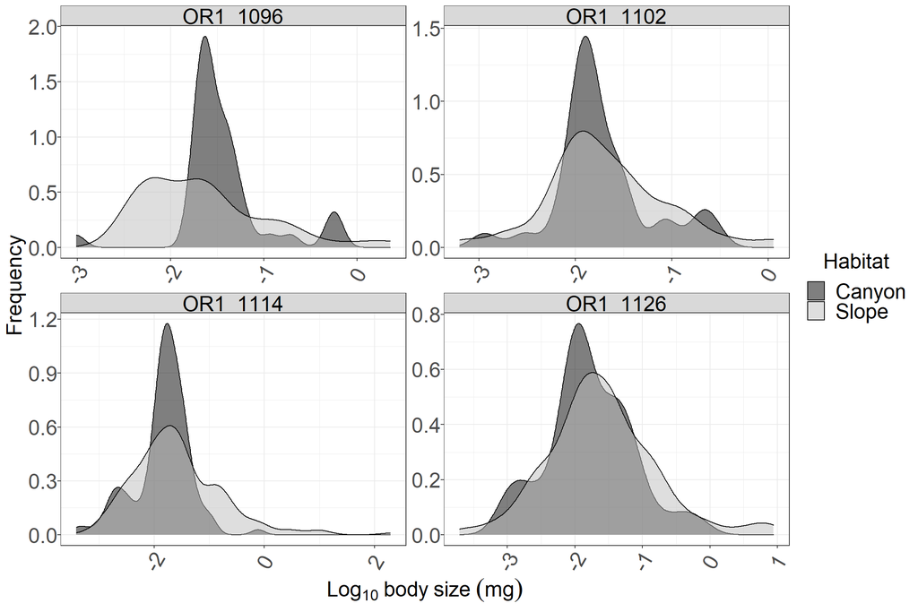

```r
# Size (complete macrofauna specimen)
mac_c <- subset(mac, Condition=="C")
mac_c <- splitBy(~Category+Cruise+Station, mac_c)

# Abundance (specimen with head)
mac_a <- subset(mac, !(Condition=="F" | is.na(Condition)))
mac_a <- summaryBy(Taxon~Category+Cruise+Station+Deployment+Tube, data=mac_a, FUN=length, var.names="Abundance", keep.names=TRUE)

# Average by Cruise/Station and then scale the abundance to 1 multicore tubes
mac_a <- summaryBy(Abundance~Category+Cruise+Station, data=mac_a, FUN=mean, var.names="Abundance", keep.names=TRUE)
mac_a$Abundance <- mac_a$Abundance

# Total abundance in each sample
sn <- with(mac_a, paste(Category, Cruise, Station, sep="|"))
abund <- mac_a[match(names(mac_c), sn),]$Abundance

# Resample the size data (with replacement) by the total abundance in each sample
sample_fun <-
  function(i){
    keep <- sample(1:dim(mac_c[[i]])[1], si=abund[i], replace=TRUE)
    mac_c[[i]][keep,]
  }

# Simulated macrofauna size data
cl<-makeCluster(4) # change the 4 to your number of CPU cores
registerDoSNOW(cl) # register the SNOW parallel backend with the foreach package
simu <- foreach(i=1:length(mac_c)) %dopar% sample_fun(i)
stopCluster(cl) # stop a SNOW cluster

ggplot(data=ldply(simu),
       aes(x=log10(Wt), fill=Habitat))+
  geom_density(alpha=0.5)+
  scale_fill_manual(values=c("black", "gray"))+
  facet_wrap(~Cruise, scales="free")+
  labs(y="Frequency", x=expression(Log[10]~body~size~(mg)))+
  theme_bw() %+replace% large #%+replace% dark
```

```r
mac_s <- ldply(simu)
```

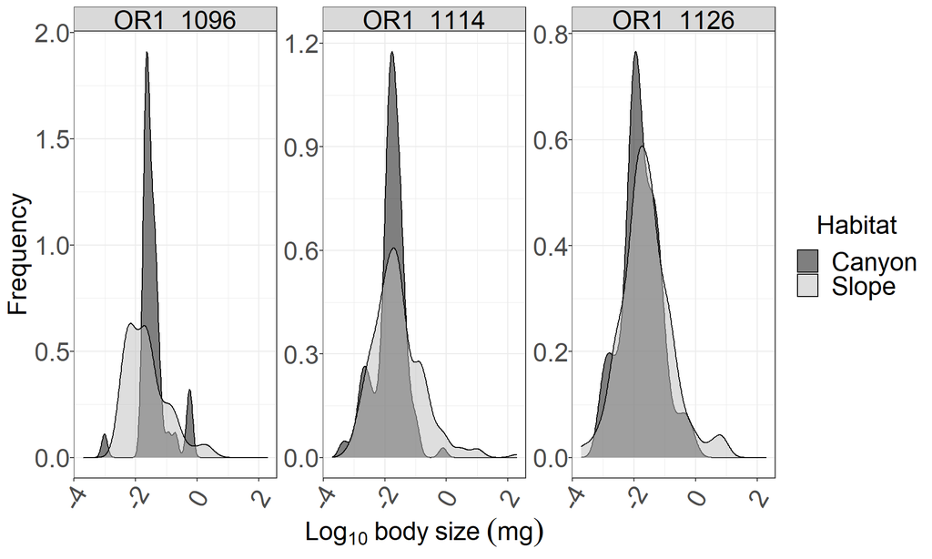

```r
# Only show 1096, 1114, 1126 macrofauna size simulation because only these cruise have ok polychaete sizes
ggplot(data=subset(mac_s, Cruise=="OR1_1096"|Cruise=="OR1_1114"|Cruise=="OR1_1126"),
       aes(x=log10(Wt), fill=Habitat))+
  geom_density(alpha=0.5)+
  scale_fill_manual(values=c("black", "gray"))+
  facet_wrap(~Cruise, scales="free_y")+
  labs(y="Frequency", x=expression(Log[10]~body~size~(mg)))+
  theme_bw() %+replace% large #%+replace% dark
```

Only cruise 1096, 1114, 1126 can be merged

# Simulated meiofauna size distribtution

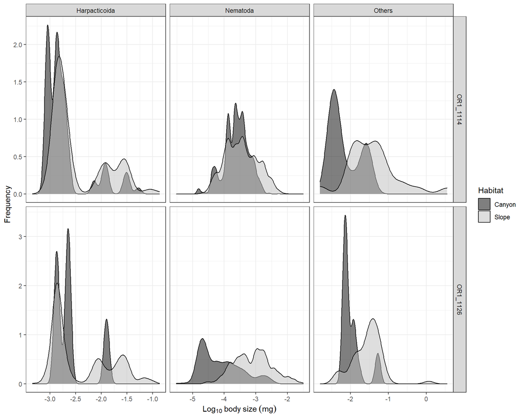

```r
# Sorting data
mei_a   <- read_excel("../excel/GPSC_meio_sorting_2016.08.18.xlsx", sheet=2)
Category <- as.character(mei_a$Taxon)
Category[Category=="Copepoda"] <- "Harpacticoida"
Category[Category!="Nematoda"&Category!="Harpacticoida"] <- "Others"
mei_a <- cbind(Category, mei_a)
mei_a <- subset(mei_a, Subcore!="water")
mei_a <- summaryBy(Abundance~Category+Cruise+Station+Taxon, data=mei_a, FUN=c(mean, sd, length), keep.names=T)
names(mei_a)[5:7] <- c("Abundance", "sd", "n")

# Scale the meiofauna abundance to the area of 1 multicore tube
mei_a$Abundance <- round(mei_a$Abundance*(10.5/2)^2/(2.5/2)^2)
mei_a$sd <- round(mei_a$sd*(10.5/2)^2/(2.5/2)^2)

# Match the sample names (tube) in size data to the sample names (tube) in sorting data
# Extract the total abudance from the sorting data
sn <- with(mei_a, paste(Category, Cruise, Station, sep="|"))
mei <- splitBy(~Category+Cruise+Station, mei)
abund <- mei_a[match(names(mei), sn),]$Abundance

# Resample the size data (with replacement) by the total abundance in each sample
sample_fun <-
  function(i){
    keep <- sample(1:dim(mei[[i]])[1], si=abund[i], replace=TRUE)
    mei[[i]][keep,]
  }

# Simulated size data
cl<-makeCluster(4) # change the 4 to your number of CPU cores
registerDoSNOW(cl) # register the SNOW parallel backend with the foreach package
simu <- foreach(i=1:length(mei)) %dopar% sample_fun(i)
stopCluster(cl) # stop a SNOW cluster

ggplot(data=subset(ldply(simu), Cruise=="OR1_1114"|Cruise=="OR1_1126"),
       aes(x=log10(Wt), fill=Habitat))+
  geom_density(alpha=0.5)+
  scale_fill_manual(values=c("black", "gray"))+
  facet_grid(Cruise~Category, scale="free")+
  labs(y="Frequency", x=expression(Log[10]~body~size~(mg)))+
  theme_bw() #%+replace% dark
```

```r
mei_s <- ldply(simu)
```

Only 1114, 1126 meiofauna can be merged with macrofauna

# Merge meiofauna and macrofauna

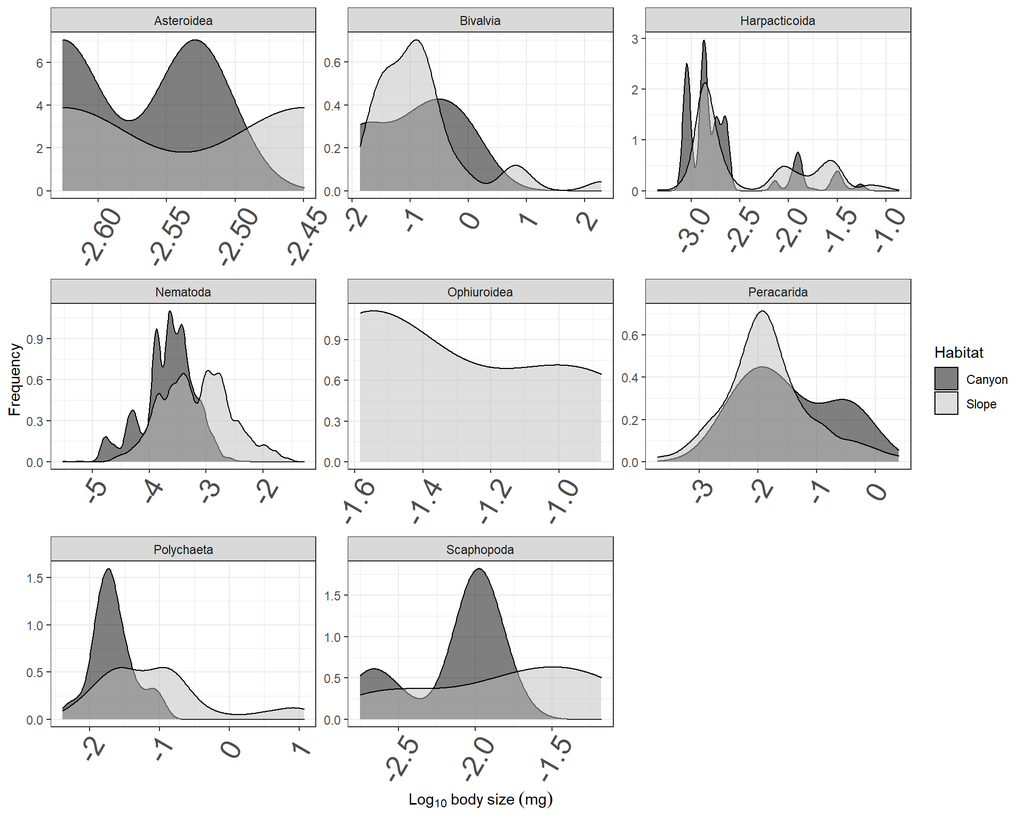

```r
# OR1 1114, 1126
si <- merge(cbind(Class="Meiofauna", mei_s), cbind(Class="Macrofauna", mac_s), all=T)
si$Habitat <- factor(si$Habitat, levels=c("Canyon", "Slope"))

# Only use 1126 data in which the meiofauna data are available
si <- si[grep("1114|1126", si$Cruise),]

ggplot(data=subset(si, Category!="Others"),
       aes(x=log10(Wt), fill=Habitat))+
  geom_density(alpha=0.5)+
  facet_wrap(~Category, scales="free")+
  scale_fill_manual(values=c("black", "gray"))+
  labs(y="Frequency", x=expression(Log[10]~body~size~(mg)))+
  theme_bw() %+replace% rotate #%+replace% dark
```

```r
save(si, file="../data/si.rda")
```